# Datacamp - Communicating with Data in the Tidyverse

Reduction in working hours and increase in hourly wages in Europe between 1996 and 2006

A. Rasheed Narejo

06-07-2018

## 0.1 Summary

The objective of this assignment is to use tidyverse package and Rmarkdown to create professional quality graphs and documents.

The **International Labour Organization** (ILO) has many data sets on working conditions. For example, one can look at how weekly working hours have been decreasing in many countries of the world, while monetary compensation has risen. In this report, the reduction in weekly working hours in European countries is analysed, and a comparison between 1996 and 2006 is made. All analysed countries have seen a decrease in weekly working hours since 1996 – some more than others.

## 0.2 visualization of labour market data

This is a personal project to replicate the data manipulation/visualization in DataCamp course [Communicating with Data in the Tidyverse](https://www.datacamp.com/courses/communicating-with-data-in-the-tidyverse).

## 0.3 load required libraries

The project requires tidyverse packages for data manipulation(dplyr) and visualization (ggplot2).

```r
library(tidyverse)
library(ggthemes)
library(forcats)
```

## 0.4 Data access

The ilo labour market files have been downloaded and saved in local data folder. We can use also use `list.files("data")` to check the files details.

### 0.4.1 Load data

```r
# load files
load("data/ilo_hourly_compensation.RData")
load("data/ilo_working_hours.RData")
```

### 0.4.2 Merge data in one file

Since, the **hourly wages** and **working hours per week** are provided in two separate files, we will first merge two files together using inner join function on country and year to create a single data frame.

```r
ilo_data <- ilo_hourly_compensation %>%
    inner_join(ilo_working_hours, on = c(country, year))
```

### 0.4.3 Convert year and country as factor variables

```r
ilo_data$year <- as.numeric(ilo_data$year)

ilo_data_factored <- ilo_data %>%
  mutate(year = as.factor(year),
        country = as.factor(country))
```

As data exploration, we can check first few rows of data to get an idea of it. We can use knitr package to beautify the tables.

```r
ilo_data_factored %>%
    head() %>%
      knitr::kable()
```

| country | year | hourly_compensation | working_hours |
| --- | --- | --- | --- |
| Australia | 1980 | 8.44 | 34.57885 |
| Canada | 1980 | 8.87 | 34.85000 |
| Denmark | 1980 | 10.83 | 31.89808 |
| Finland | 1980 | 8.61 | 35.56346 |
| France | 1980 | 8.90 | 35.42308 |
| Italy | 1980 | 8.09 | 35.74635 |

Our primary objective for this assignment is to check the weekly hours worked and average hourly wage trend in European countries.

```r
# vector of all european countries
european_countries <- c("Finland", "France", "Italy", "Norway", "Spain", "Sweden", "Switzerland", "United Kingdom", "Belgium", "Ireland", "Luxembourg", "Portugal", "Netherlands", "Germany", "Hungary", "Austria", "Czech Rep.")
```

As a first step, lets check trend of average working hours and average hourly wages across europe over the years.

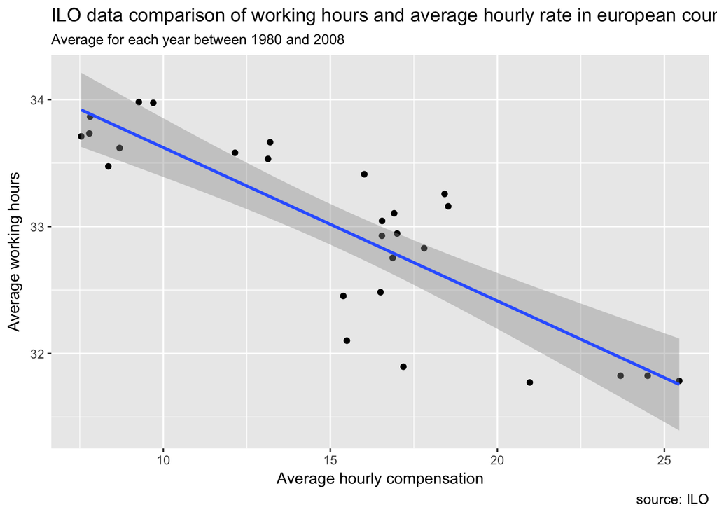

```r
ilo_data_factored %>%
  filter(country %in% european_countries) %>%
  group_by(year) %>%
  summarise(avg_hourly_compensation = mean(hourly_compensation),
            avg_working_hours = mean(working_hours)) %>%
    ggplot(aes(x = avg_hourly_compensation, y = avg_working_hours)) +
      geom_point() +
      geom_smooth(method='lm') +
      labs(x = "Average hourly compensation",
           y = "Average working hours",
           title = "ILO data comparison of working hours and average hourly rate in european countries",
           subtitle = "Average for each year between 1980 and 2008",
           caption = "source: ILO")
```

There is a definitive trend of increasing hourly wages and declining average weekly working hours over the years.

```r
ilo_data_final <- ilo_data_factored %>%
    filter(country %in% european_countries) %>%
    filter(year == 1996 | year == 2006)
```

```r
# Some summary statistics
ilo_data_final %>%
  group_by(year) %>%
  summarize(mean_hourly_compensation = mean(hourly_compensation),
            mean_working_hours = mean(working_hours)) %>%
  knitr::kable()
```

| year | mean_hourly_compensation | mean_working_hours |
| --- | --- | --- |
| 1996 | 18.52882 | 33.15975 |
| 2006 | 25.44647 | 31.78460 |